# Exercise 15

## Fitting K nearest Model for Trinary Classifier

Generating KNN Models for Trinary Classifier Data and Displaying their accuracy from K=1 to K=25

```r
K_Trinary_Values <- c()
Accuracy_Trinary <- c()
error.rate.t <- c()
# Running for multiple K Values
for(i in 1:25){
  knnmodel.t.i <- knn(train_trinary[2:3],test_trinary[2:3],k=i,cl=train_trinary$label)
  table.t.i <- table(knnmodel.t.i,test_trinary$label)
  accur = accuracy(table.t.i)
  print(paste("Accuracy for Trinary Classifier Data Model with K=", i ," is ", accur))
  K_Trinary_Values <- c(K_Trinary_Values, i)
  Accuracy_Trinary<- c(Accuracy_Trinary, accur)
  error.rate.t <- c(error.rate.t, mean(test_trinary$label != knnmodel.t.i))
}
```

```
## [1] "Accuracy for Trinary Classifier Data Model with K= 1  is  90.4153354632588"
## [1] "Accuracy for Trinary Classifier Data Model with K= 2  is  91.0543130990415"
## [1] "Accuracy for Trinary Classifier Data Model with K= 3  is  91.0543130990415"
## [1] "Accuracy for Trinary Classifier Data Model with K= 4  is  89.776357827476"
## [1] "Accuracy for Trinary Classifier Data Model with K= 5  is  90.0958466453674"
## [1] "Accuracy for Trinary Classifier Data Model with K= 6  is  90.4153354632588"
## [1] "Accuracy for Trinary Classifier Data Model with K= 7  is  91.0543130990415"
## [1] "Accuracy for Trinary Classifier Data Model with K= 8  is  91.0543130990415"
## [1] "Accuracy for Trinary Classifier Data Model with K= 9  is  91.3738019169329"
## [1] "Accuracy for Trinary Classifier Data Model with K= 10  is  91.3738019169329"
## [1] "Accuracy for Trinary Classifier Data Model with K= 11  is  90.4153354632588"
## [1] "Accuracy for Trinary Classifier Data Model with K= 12  is  90.7348242811502"
## [1] "Accuracy for Trinary Classifier Data Model with K= 13  is  91.0543130990415"
## [1] "Accuracy for Trinary Classifier Data Model with K= 14  is  90.4153354632588"
## [1] "Accuracy for Trinary Classifier Data Model with K= 15  is  89.776357827476"
## [1] "Accuracy for Trinary Classifier Data Model with K= 16  is  89.776357827476"
## [1] "Accuracy for Trinary Classifier Data Model with K= 17  is  90.0958466453674"
## [1] "Accuracy for Trinary Classifier Data Model with K= 18  is  88.8178913738019"
## [1] "Accuracy for Trinary Classifier Data Model with K= 19  is  89.776357827476"
## [1] "Accuracy for Trinary Classifier Data Model with K= 20  is  89.4568690095847"
## [1] "Accuracy for Trinary Classifier Data Model with K= 21  is  89.4568690095847"
## [1] "Accuracy for Trinary Classifier Data Model with K= 22  is  88.4984025559105"
## [1] "Accuracy for Trinary Classifier Data Model with K= 23  is  89.1373801916933"
## [1] "Accuracy for Trinary Classifier Data Model with K= 24  is  89.4568690095847"
## [1] "Accuracy for Trinary Classifier Data Model with K= 25  is  89.1373801916933"
```

```r
print(K_Trinary_Values)
```

```
##  [1]  1  2  3  4  5  6  7  8  9 10 11 12 13 14 15 16 17 18 19 20 21 22 23 24 25
```

```r
print(Accuracy_Trinary)
```

```
##  [1] 90.41534 91.05431 91.05431 89.77636 90.09585 90.41534 91.05431 91.05431
##  [9] 91.37380 91.37380 90.41534 90.73482 91.05431 90.41534 89.77636 89.77636
## [17] 90.09585 88.81789 89.77636 89.45687 89.45687 88.49840 89.13738 89.45687
## [25] 89.13738
```

```r
print(error.rate.t*100)
```

```
##  [1]  9.584665  8.945687  8.945687 10.223642  9.904153  9.584665  8.945687
##  [8]  8.945687  8.626198  8.626198  9.584665  9.265176  8.945687  9.584665
## [15] 10.223642 10.223642  9.904153 11.182109 10.223642 10.543131 10.543131
## [22] 11.501597 10.862620 10.543131 10.862620
```

```r
print(Accuracy_Trinary+error.rate.t*100)
```

```
##  [1] 100 100 100 100 100 100 100 100 100 100 100 100 100 100 100 100 100 100 100
## [20] 100 100 100 100 100 100
```

```r
accuracy_trinary_df <- data.frame(K_Trinary_Values, Accuracy_Trinary, error.rate.t*100)
accuracy_trinary_df
```

```
##    K_Trinary_Values Accuracy_Trinary error.rate.t...100
## 1                 1         90.41534           9.584665
## 2                 2         91.05431           8.945687
## 3                 3         91.05431           8.945687
## 4                 4         89.77636          10.223642
## 5                 5         90.09585           9.904153
## 6                 6         90.41534           9.584665
## 7                 7         91.05431           8.945687
## 8                 8         91.05431           8.945687
## 9                 9         91.37380           8.626198
## 10               10         91.37380           8.626198
## 11               11         90.41534           9.584665
## 12               12         90.73482           9.265176
## 13               13         91.05431           8.945687
## 14               14         90.41534           9.584665
## 15               15         89.77636          10.223642
## 16               16         89.77636          10.223642
## 17               17         90.09585           9.904153
## 18               18         88.81789          11.182109
## 19               19         89.77636          10.223642
## 20               20         89.45687          10.543131
## 21               21         89.45687          10.543131
## 22               22         88.49840          11.501597
## 23               23         89.13738          10.862620
## 24               24         89.45687          10.543131
## 25               25         89.13738          10.862620
```

## Plotting the K Values vs Accuracy

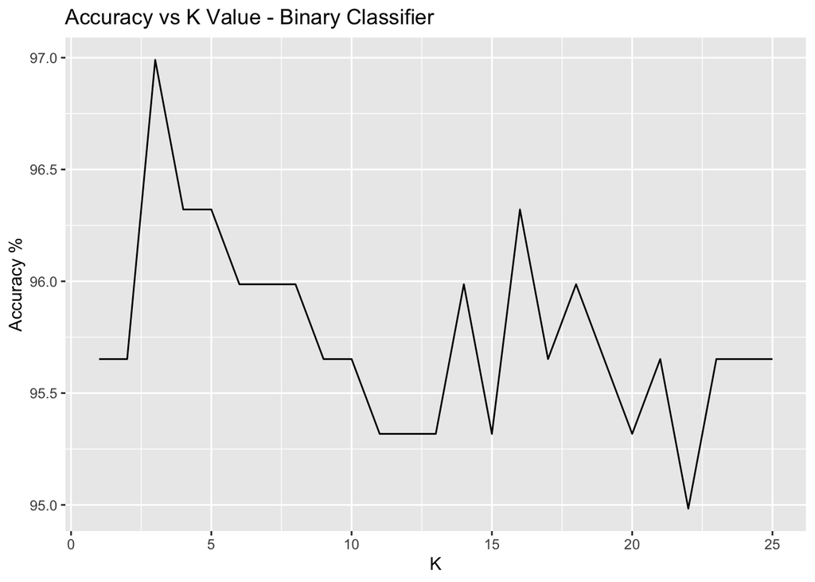

```r
library(ggplot2)
ggplot(data = accuracy_binary_df, aes(y = Accuracy_Binary, x = K_Binary_Values)) +
  geom_line() + ggtitle("Accuracy vs K Value - Binary Classifier") +
  ylab("Accuracy %") + xlab("K")
```

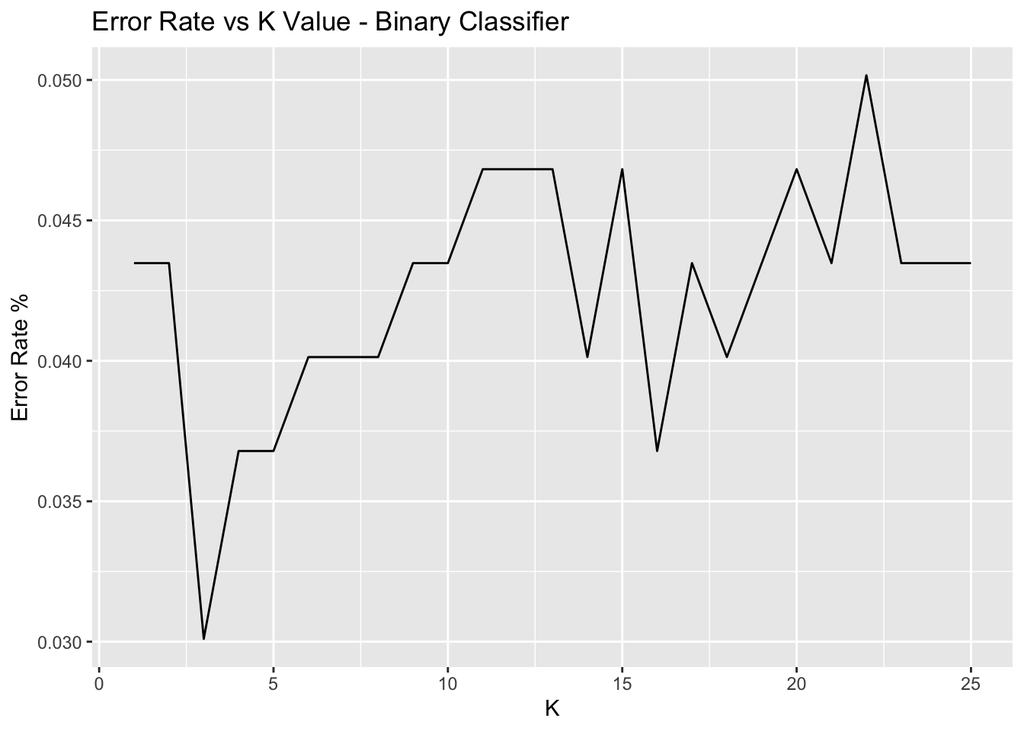

```r
# Inverted Plot of Above
ggplot(data = accuracy_binary_df, aes(y = error.rate.b, x = K_Binary_Values)) +
  geom_line() + ggtitle("Error Rate vs K Value - Binary Classifier") +
  ylab("Error Rate %") + xlab("K")
```

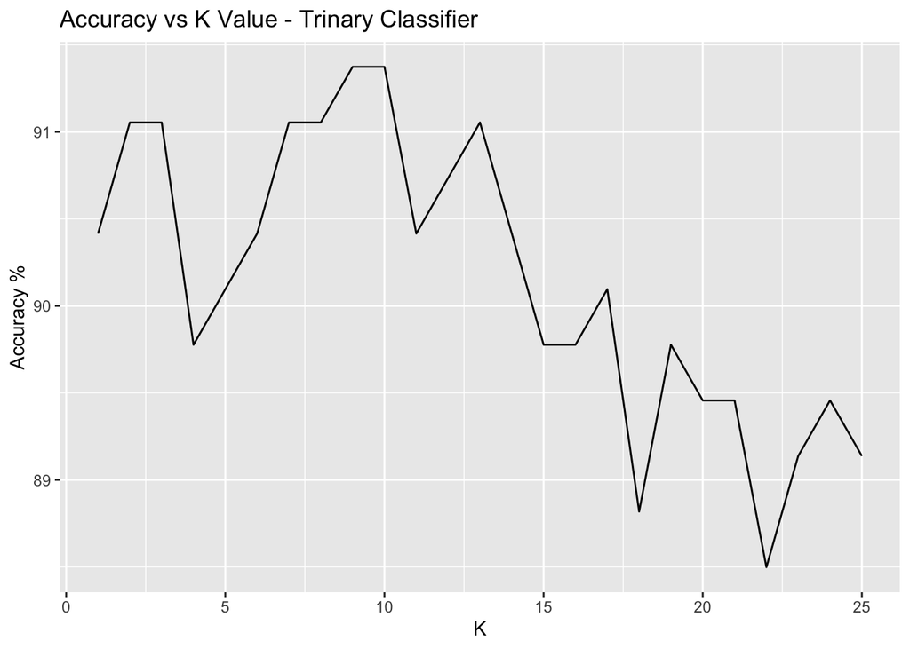

```r
ggplot(data = accuracy_trinary_df, aes(y = Accuracy_Trinary, x = K_Trinary_Values)) +
  geom_line() + ggtitle("Accuracy vs K Value - Trinary Classifier") +
  ylab("Accuracy %") + xlab("K")
```

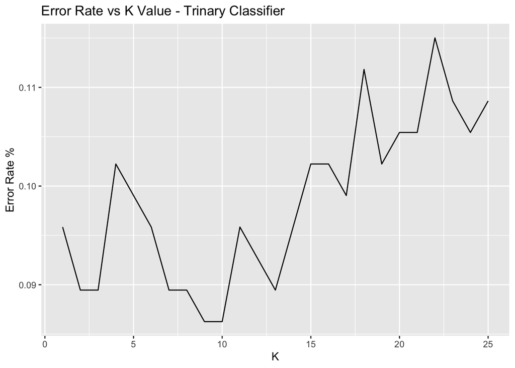

```r
# Inverted Plot of Above
ggplot(data = accuracy_trinary_df, aes(y = error.rate.t, x = K_Trinary_Values)) +
  geom_line() + ggtitle("Error Rate vs K Value - Trinary Classifier") +
  ylab("Error Rate %") + xlab("K")
```

# c. In later lessons, you will learn about linear classifiers. These algorithms work by defining a decision boundary that separates the different categories. Looking back at the plots of the data, do you think a linear classifier would work well on these datasets?

If we look at the Actual Data, its hard to divide the data(colored dots) with a line / linear classifier as the data is spread in different clusters. It is not possible to put the different binary values in opposite direction of this line, So linear classifier will not work with this kind of dataset.

# Reference

https://towardsdatascience.com/k-nearest-neighbors-algorithm-with-examples-in-r-simply-explained-knn-1f2c88da405c